# Project: Analysing presence of Patients on Appointment

- Introduction
- Data Wrangling
- Exploratory Data Analysis
- Predictive Analysis
- Conclusions

## Introduction

> This dataset collects information from 100k medical appointments in Brazil and is focused on the question of whether or not patients show up for their appointment. A number of characteristics about the patient are included in each row.

> ScheduledDay tells us on what day the patient set up their appointment. Neighborhood indicates the location of the hospital.

> Scholarship indicates whether or not the patient is enrolled in Brasilian welfare program Bolsa Família.

> Encoding of the last column: it says ‘No’ if the patient showed up to their appointment, and ‘Yes’ if they did not show up.

> Is there any significant trend regarding presence of patients depending upon Gender,Age etc ? Is there some disparity among patients who did not show up at the time of appoitnment based on some disease or gender?

> Performing predictive analysis has been performed below after the analysis part and the accuracy of both testing dataset and training dataset have been checked

```python
# Importing packages planned to use for data analysis and predictive analysis.
import pandas as pd
import numpy as np
import statsmodels.api as sm
import matplotlib.pyplot as plt
%matplotlib inline
```

## Data Wrangling

> Accessing and cleaning data

### General Properties

```python
# Loading and printing out a few lines. Perform operations to inspect data
df=pd.read_csv('noshowappointments-kagglev2-may-2016.csv')
df.head(3)
```

|  | PatientId | AppointmentID | Gender | ScheduledDay | AppointmentDay | Age | Neighbourhood | Scholarship | Hipertension | Diabetes | Alcoholism | Handcap | SMS_received | No-show |
| --- | --- | --- | --- | --- | --- | --- | --- | --- | --- | --- | --- | --- | --- | --- |
| 0 | 2.987250e+13 | 5642903 | F | 2016-04-29T18:38:08Z | 2016-04-29T00:00:00Z | 62 | JARDIM DA PENHA | 0 | 1 | 0 | 0 | 0 | 0 | No |
| 1 | 5.589978e+14 | 5642503 | M | 2016-04-29T16:08:27Z | 2016-04-29T00:00:00Z | 56 | JARDIM DA PENHA | 0 | 0 | 0 | 0 | 0 | 0 | No |
| 2 | 4.262962e+12 | 5642549 | F | 2016-04-29T16:19:04Z | 2016-04-29T00:00:00Z | 62 | MATA DA PRAIA | 0 | 0 | 0 | 0 | 0 | 0 | No |

```python
#Performing operations to inspect data types and look for instances of missing or possibly errant data.
df.info()
```

```
<class 'pandas.core.frame.DataFrame'>
RangeIndex: 110527 entries, 0 to 110526
Data columns (total 14 columns):
PatientId         110527 non-null float64
AppointmentID     110527 non-null int64
Gender            110527 non-null object
ScheduledDay      110527 non-null object
AppointmentDay    110527 non-null object
Age               110527 non-null int64
Neighbourhood     110527 non-null object
Scholarship       110527 non-null int64
Hipertension      110527 non-null int64
Diabetes          110527 non-null int64
Alcoholism        110527 non-null int64
Handcap           110527 non-null int64
SMS_received      110527 non-null int64
No-show           110527 non-null object
dtypes: float64(1), int64(8), object(5)
memory usage: 11.8+ MB
```

### Data Cleaning

> Here I have converted the two columns of Appointment Day and Scheduled Day to date time format.Renamed columns as per requirement

> Descriptive statistic of each column has been accessed so as to ensure that there is not any discrepancy in data and if found that particular row has been removed.

> The entire dataset has been filtered in two parts as per their presence on the appointment day.

```python
# Converting ScheduledDay and AppointmentDay to datetime format and further checking for clarity.
df['ScheduledDay']=pd.to_datetime(df['ScheduledDay'])
df['AppointmentDay']=pd.to_datetime(df['AppointmentDay'])
df.info()
```

```
<class 'pandas.core.frame.DataFrame'>
RangeIndex: 110527 entries, 0 to 110526
Data columns (total 14 columns):
PatientId         110527 non-null float64
AppointmentID     110527 non-null int64
Gender            110527 non-null object
ScheduledDay      110527 non-null datetime64[ns]
AppointmentDay    110527 non-null datetime64[ns]
Age               110527 non-null int64
Neighbourhood     110527 non-null object
Scholarship       110527 non-null int64
Hipertension      110527 non-null int64
Diabetes          110527 non-null int64
Alcoholism        110527 non-null int64
Handcap           110527 non-null int64
SMS_received      110527 non-null int64
No-show           110527 non-null object
dtypes: datetime64[ns](2), float64(1), int64(8), object(3)
memory usage: 11.8+ MB
```

```python
# Renaming columns as per requirement
df=df.rename(columns ={'No-show':'No_show'})
```

```python
# To get descriptive statistics for each column
df.describe()
```

|  | PatientId | AppointmentID | Age | Scholarship | Hipertension | Diabetes | Alcoholism | Handcap | SMS_received |
| --- | --- | --- | --- | --- | --- | --- | --- | --- | --- |
| count | 1.105270e+05 | 1.105270e+05 | 110527.000000 | 110527.000000 | 110527.000000 | 110527.000000 | 110527.000000 | 110527.000000 | 110527.000000 |
| mean | 1.474963e+14 | 5.675305e+06 | 37.088874 | 0.098266 | 0.197246 | 0.071865 | 0.030400 | 0.022248 | 0.321026 |
| std | 2.560949e+14 | 7.129575e+04 | 23.110205 | 0.297675 | 0.397921 | 0.258265 | 0.171686 | 0.161543 | 0.466873 |
| min | 3.921784e+04 | 5.030230e+06 | -1.000000 | 0.000000 | 0.000000 | 0.000000 | 0.000000 | 0.000000 | 0.000000 |
| 25% | 4.172614e+12 | 5.640286e+06 | 18.000000 | 0.000000 | 0.000000 | 0.000000 | 0.000000 | 0.000000 | 0.000000 |
| 50% | 3.173184e+13 | 5.680573e+06 | 37.000000 | 0.000000 | 0.000000 | 0.000000 | 0.000000 | 0.000000 | 0.000000 |
| 75% | 9.439172e+13 | 5.725524e+06 | 55.000000 | 0.000000 | 0.000000 | 0.000000 | 0.000000 | 0.000000 | 1.000000 |
| max | 9.999816e+14 | 5.790484e+06 | 115.000000 | 1.000000 | 1.000000 | 1.000000 | 1.000000 | 4.000000 | 1.000000 |

> It is clear from above descriptive statistics that majority of the patients included in the dataset

> Did not receive Scholarship.

> Don't suffer from Hipertension.

> Don't suffer from Diabetes.

> Don't suffer from Alcoholism.

> Aren't Handicapped.

```python
# As it is clear from above data that the minimum age is negative which is not possible so dropping
# that partcular row
df.query('Age <0')
```

|  | PatientId | AppointmentID | Gender | ScheduledDay | AppointmentDay | Age | Neighbourhood | Scholarship | Hipertension | Diabetes | Alcoholism | Handcap | SMS_received | No_show |
| --- | --- | --- | --- | --- | --- | --- | --- | --- | --- | --- | --- | --- | --- | --- |
| 99832 | 4.659432e+14 | 5775010 | F | 2016-06-06 08:58:13 | 2016-06-06 | -1 | ROMÃO | 0 | 0 | 0 | 0 | 0 | 0 | No |

```python
# Dropping that particular row
df.drop(df.index[99832],inplace=True)
```

```python
# Checking the result
df.query('Age <0')
```

|  | PatientId | AppointmentID | Gender | ScheduledDay | AppointmentDay | Age | Neighbourhood | Scholarship | Hipertension | Diabetes | Alcoholism | Handcap | SMS_received | No_show |
| --- | --- | --- | --- | --- | --- | --- | --- | --- | --- | --- | --- | --- | --- | --- |

```python
#Filtering the dataset on the basis of patients who did show up at the appointment and those who
# didn't, further dividing them into two different datasets.
df1=df.query('No_show == "No" ')
df2=df.query('No_show == "Yes" ')
```

```python
df1.describe()
```

|  | PatientId | AppointmentID | Age | Scholarship | Hipertension | Diabetes | Alcoholism | Handcap | SMS_received |
| --- | --- | --- | --- | --- | --- | --- | --- | --- | --- |
| count | 8.820700e+04 | 8.820700e+04 | 88207.000000 | 88207.000000 | 88207.000000 | 88207.000000 | 88207.000000 | 88207.000000 | 88207.000000 |
| mean | 1.476809e+14 | 5.681135e+06 | 37.790504 | 0.093904 | 0.204394 | 0.073838 | 0.030417 | 0.022742 | 0.291337 |
| std | 2.563739e+14 | 6.931193e+04 | 23.338645 | 0.291697 | 0.403261 | 0.261508 | 0.171733 | 0.162751 | 0.454381 |
| min | 3.921784e+04 | 5.030230e+06 | 0.000000 | 0.000000 | 0.000000 | 0.000000 | 0.000000 | 0.000000 | 0.000000 |
| 25% | 4.168386e+12 | 5.646218e+06 | 18.000000 | 0.000000 | 0.000000 | 0.000000 | 0.000000 | 0.000000 | 0.000000 |
| 50% | 3.176138e+13 | 5.685683e+06 | 38.000000 | 0.000000 | 0.000000 | 0.000000 | 0.000000 | 0.000000 | 0.000000 |
| 75% | 9.433684e+13 | 5.731078e+06 | 56.000000 | 0.000000 | 0.000000 | 0.000000 | 0.000000 | 0.000000 | 1.000000 |
| max | 9.999816e+14 | 5.790484e+06 | 115.000000 | 1.000000 | 1.000000 | 1.000000 | 1.000000 | 4.000000 | 1.000000 |

From the above descriptive statistics of df1 it is clear that among the patients who did attend the appointment

> Majority were not suffering from any type of disease mentioned in the dataset viz Hipertension,Diabetes etc.

> Majority did not receive the Scholarship.

```python
df2.describe()
```

|  | PatientId | AppointmentID | Age | Scholarship | Hipertension | Diabetes | Alcoholism | Handcap | SMS_received |
| --- | --- | --- | --- | --- | --- | --- | --- | --- | --- |
| count | 2.231900e+04 | 2.231900e+04 | 22319.000000 | 22319.000000 | 22319.000000 | 22319.000000 | 22319.000000 | 22319.000000 | 22319.000000 |
| mean | 1.467523e+14 | 5.652259e+06 | 34.317667 | 0.115507 | 0.169004 | 0.064071 | 0.030333 | 0.020297 | 0.438371 |
| std | 2.549905e+14 | 7.429686e+04 | 21.965941 | 0.319640 | 0.374764 | 0.244885 | 0.171505 | 0.156670 | 0.496198 |
| min | 5.628261e+06 | 5.122866e+06 | 0.000000 | 0.000000 | 0.000000 | 0.000000 | 0.000000 | 0.000000 | 0.000000 |
| 25% | 4.176779e+12 | 5.614192e+06 | 16.000000 | 0.000000 | 0.000000 | 0.000000 | 0.000000 | 0.000000 | 0.000000 |
| 50% | 3.156794e+13 | 5.657916e+06 | 33.000000 | 0.000000 | 0.000000 | 0.000000 | 0.000000 | 0.000000 | 0.000000 |
| 75% | 9.454270e+13 | 5.703175e+06 | 51.000000 | 0.000000 | 0.000000 | 0.000000 | 0.000000 | 0.000000 | 1.000000 |
| max | 9.996585e+14 | 5.789986e+06 | 115.000000 | 1.000000 | 1.000000 | 1.000000 | 1.000000 | 4.000000 | 1.000000 |

From the above descriptive statistics of df2 it is clear that among the patients who did not attend the appointment

> Majority were not suffering from any type of disease mentioned in the dataset viz Hipertension,Diabetes etc.

> Majority did not receive the Scholarship.

> As it can be seen above there is a wide variation in the age of the patients present so adding a new column Age_group which will show in which category does the patients belong.

> Category is divided as

> Age <18 Minor

> 18<Age<30 Adult

> 30<Age<60 Mature

> 60<Age Senior_Citizen

```python
# Adding new column and intialising it
df1.loc[:,'Age_group']=" "
df2.loc[:,'Age_group']=" ";
```

```python
# Checking the results
df1.head(1)
```

|  | PatientId | AppointmentID | Gender | ScheduledDay | AppointmentDay | Age | Neighbourhood | Scholarship | Hipertension | Diabetes | Alcoholism | Handcap | SMS_received | No_show | Age_group |
| --- | --- | --- | --- | --- | --- | --- | --- | --- | --- | --- | --- | --- | --- | --- | --- |
| 0 | 2.987250e+13 | 5642903 | F | 2016-04-29 18:38:08 | 2016-04-29 | 62 | JARDIM DA PENHA | 0 | 1 | 0 | 0 | 0 | 0 | No |  |

```python
# Filling the new column with values as defined above
w=df1['Age']
for i,c in enumerate(w):
    if (c<=18):
        df1.iloc[i,-1]='Minor'
    elif(c>18 and c<=30):
        df1.iloc[i,-1]='Adult'
    elif(c>30 and c<=60):
        df1.iloc[i,-1]='Mature'
    else:
        df1.iloc[i,-1]='Senior_Citizen'
```

```python
# Similarly for df2 dataframe
w1=df2['Age']
for i,c in enumerate(w1):
    if (c<=18):
        df2.iloc[i,-1]='Minor'
    elif(c>18 and c<=30):
        df2.iloc[i,-1]='Adult'
    elif(c>30 and c<=60):
        df2.iloc[i,-1]='Mature'
    else:
        df2.iloc[i,-1]='Senior_Citizen'
```

```python
# Checking for results
df1.head(2)
```

|  | PatientId | AppointmentID | Gender | ScheduledDay | AppointmentDay | Age | Neighbourhood | Scholarship | Hipertension | Diabetes | Alcoholism | Handcap | SMS_received | No_show | Age_group |
| --- | --- | --- | --- | --- | --- | --- | --- | --- | --- | --- | --- | --- | --- | --- | --- |
| 0 | 2.987250e+13 | 5642903 | F | 2016-04-29 18:38:08 | 2016-04-29 | 62 | JARDIM DA PENHA | 0 | 1 | 0 | 0 | 0 | 0 | No | Senior_Citizen |
| 1 | 5.589978e+14 | 5642503 | M | 2016-04-29 16:08:27 | 2016-04-29 | 56 | JARDIM DA PENHA | 0 | 0 | 0 | 0 | 0 | 0 | No | Mature |

```python
# Similarly checking for df2
df2.head(2)
```

|  | PatientId | AppointmentID | Gender | ScheduledDay | AppointmentDay | Age | Neighbourhood | Scholarship | Hipertension | Diabetes | Alcoholism | Handcap | SMS_received | No_show | Age_group |
| --- | --- | --- | --- | --- | --- | --- | --- | --- | --- | --- | --- | --- | --- | --- | --- |
| 6 | 7.336882e+14 | 5630279 | F | 2016-04-27 15:05:12 | 2016-04-29 | 23 | GOIABEIRAS | 0 | 0 | 0 | 0 | 0 | 0 | Yes | Adult |
| 7 | 3.449833e+12 | 5630575 | F | 2016-04-27 15:39:58 | 2016-04-29 | 39 | GOIABEIRAS | 0 | 0 | 0 | 0 | 0 | 0 | Yes | Mature |

## Exploratory Data Analysis

>

## Is there any difference in age group distribution for those who did show up at the appointment and those who didn't?

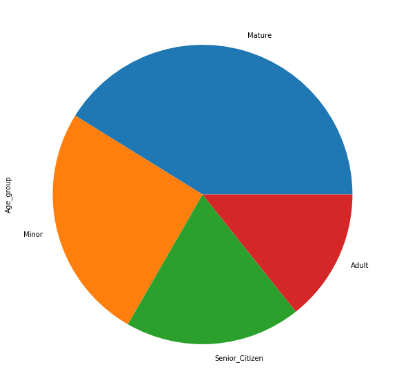

```python
# Using pie-chart to answer the above question for both sections od dataset df1 and df2.
# For df1 the Pie-chart is
age_dist=df1['Age_group'].value_counts()
age_dist.plot(kind='pie',figsize=(20,10));
```

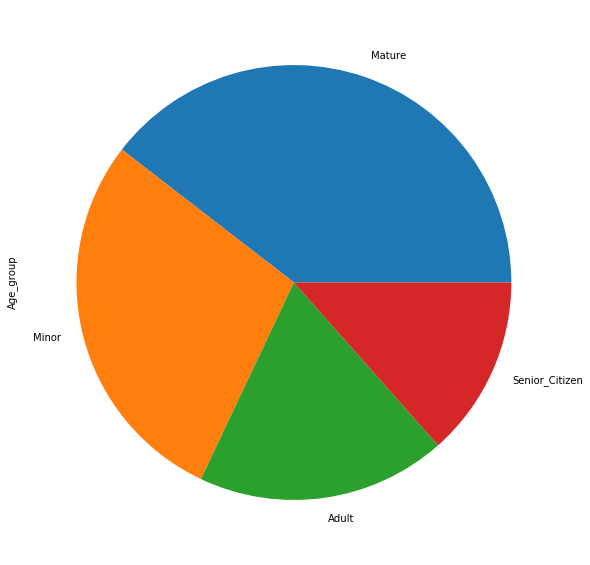

```python
# Similarly for df2 dataset
age_dist1=df2['Age_group'].value_counts()
age_dist1.plot(kind='pie',figsize=(20,10));
```

## From the above two charts it can be concluded that the proportion of Mature and Minor age group in both df1 and df2 datasets are approximately same,but the proportions for Adult and Senior Citizen age groups are different for each subset of dataframe.

### What proportion of patients received scholarship who did attend the appointment(trying to get an insight whether scholarship does impact their presence for the appointment)?

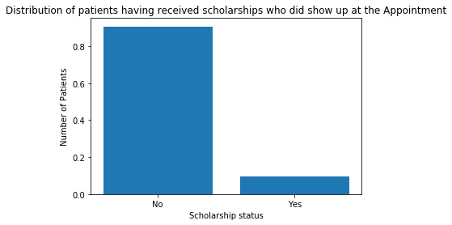

```python
# Here bar charts have been used to compare the proportions of students who received scholarships
# Comparing the proportions for those who did show up at the appointment
c1=df1['Scholarship'].value_counts()
k=["No","Yes"]
plt.bar(k,[c1[0]/(c1[0]+c1[1]),c1[1]/(c1[0]+c1[1])])
plt.title("Distribution of patients having received scholarships who did show up at the Appointment")
plt.xlabel("Scholarship status")
plt.ylabel("Number of Patients");
```

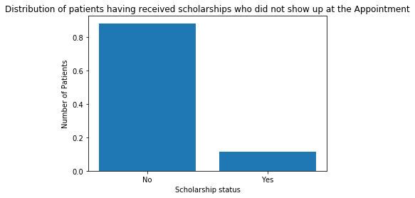

```python
# Similarly comparing the proportions for those who did not show up at the appointment
c2=df2['Scholarship'].value_counts()
plt.bar(k,[c2[0]/(c2[0]+c2[1]),c2[1]/(c2[0]+c2[1])])
plt.title("Distribution of patients having received scholarships who did not show up at the Appointment")
plt.xlabel("Scholarship status")
plt.ylabel("Number of Patients");
```

## From the above two Bar charts it is clear that the proportions of students who did receive the scholarship for both sub-datasets df1 and df2 are approximately same.

### Distribution of patients on gender basis who did not show up at the appointment but are suffering from Alcoholism

```python
# First dividing the the df2 dataset into two groups of males and females
df2_m=df2.query('Gender == "M"')
df2_f=df2.query('Gender == "F"')
```

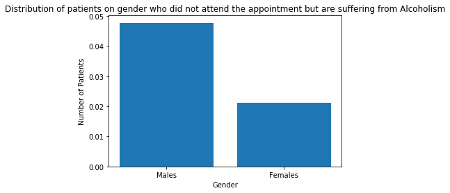

```python
# Now plotting the proportions of males and females who are suffereing from alcoholism but did not show up
# at the Appointment
count_m=df2_m['Alcoholism'].value_counts()
k1=["Males","Females"]
count_f=df2_f['Alcoholism'].value_counts()
plt.bar(k1,[count_m[1]/(count_m[1]+count_m[0]),count_f[1]/(count_f[0]+count_f[1])])
plt.title("Distribution of patients on gender who did not attend the appointment but are suffering from Alcoholism")
plt.xlabel("Gender")
plt.ylabel("Number of Patients");
```

## It can be concluded from above visualisation that the proportion of males suffering from alcoholism are more than that of women in the group of not attending the appointment.

## Predictive Analysis

Here the main dataset has been split into two parts viz training part and testing part

> On the training part logistic regression has been performed and a model has been created also it's accuracy has been tested.

> On the testing part the model obtained from training dataset is tested for it's accuracy. Generally it's accuracy is less from training part and it is higher just by luck.

```python
# Creating a copy of above dataset
data=df.copy()
```

```python
# Dropping columns
data.drop(columns=['PatientId','AppointmentID','ScheduledDay','AppointmentDay','Neighbourhood'],axis=1,inplace=True)
```

```python
# Checking for results
data.head(2)
```

|  | Gender | Age | Scholarship | Hipertension | Diabetes | Alcoholism | Handcap | SMS_received | No_show |
| --- | --- | --- | --- | --- | --- | --- | --- | --- | --- |
| 0 | F | 62 | 0 | 1 | 0 | 0 | 0 | 0 | No |
| 1 | M | 56 | 0 | 0 | 0 | 0 | 0 | 0 | No |

```python
# Mapping the values for logistic regression
data['Gender']=data['Gender'].map({'F':0,'M':1})
data['No_show']=data['No_show'].map({'No':0,'Yes':1})
```

```python
# Splitting the dataset in 9:1 ratio
train_data=data.iloc[:99474,:]
test_data=data.iloc[99474:,:]
```

### Declaring the independent variable(s)

```python
estimators=['Gender','Age','Scholarship','Hipertension','Diabetes','Alcoholism','Handcap','SMS_received']

X = train_data[estimators]
y = train_data['No_show']
```

### Performing Logistic Regression

```python
reg_log=sm.Logit(y,X)
result_log=reg_log.fit()
result_log.summary2()
```

```
Optimization terminated successfully.
         Current function value: 0.523915
         Iterations 6
```

| Model: | Logit | Pseudo R-squared: | -0.042 |
| --- | --- | --- | --- |
| Dependent Variable: | No_show | AIC: | 104247.8663 |
| Date: | 2019-01-31 10:52 | BIC: | 104323.9275 |
| No. Observations: | 99474 | Log-Likelihood: | -52116. |
| Df Model: | 7 | LL-Null: | -50016. |
| Df Residuals: | 99466 | LLR p-value: | 1.0000 |
| Converged: | 1.0000 | Scale: | 1.0000 |
| No. Iterations: | 6.0000 |  |  |

|  | Coef. | Std.Err. | z | P>\|z\| | [0.025 | 0.975] |
| --- | --- | --- | --- | --- | --- | --- |
| Gender | -0.6380 | 0.0151 | -42.2502 | 0.0000 | -0.6676 | -0.6084 |
| Age | -0.0297 | 0.0003 | -98.6616 | 0.0000 | -0.0303 | -0.0291 |
| Scholarship | -0.3342 | 0.0249 | -13.4171 | 0.0000 | -0.3830 | -0.2854 |
| Hipertension | 0.2248 | 0.0261 | 8.6109 | 0.0000 | 0.1736 | 0.2760 |
| Diabetes | 0.1911 | 0.0364 | 5.2535 | 0.0000 | 0.1198 | 0.2623 |
| Alcoholism | 0.3217 | 0.0486 | 6.6219 | 0.0000 | 0.2265 | 0.4170 |
| Handcap | -0.0050 | 0.0522 | -0.0956 | 0.9238 | -0.1072 | 0.0973 |
| SMS_received | 0.2345 | 0.0155 | 15.0914 | 0.0000 | 0.2041 | 0.2650 |

### Confusion Matrix

Find the confusion matrix of the model and estimate its accuracy.

*A function has been defined that finds the confusion matrix and the model accuracy.*

```python
def confusion_matrix(data,actual_values,model):

        # Confusion matrix

        # Parameters
        # ----------
        # data: data frame or array
            # data is a data frame formatted in the same way as your input data (without the actual values)
            # e.g. const, var1, var2, etc. Order is very important!
        # actual_values: data frame or array
            # These are the actual values from the test_data
            # In the case of a logistic regression, it should be a single column with 0s and 1s

        # model: a LogitResults object
            # this is the variable where you have the fitted model
            # e.g. results_log in this course
        # ----------

        #Predict the values using the Logit model
        pred_values = model.predict(data)
        # Specify the bins
        bins=np.array([0,0.5,1])
        # Create a histogram, where if values are between 0 and 0.5 tell will be considered 0
        # if they are between 0.5 and 1, they will be considered 1
        cm = np.histogram2d(actual_values, pred_values, bins=bins)[0]
        # Calculate the accuracy
        accuracy = (cm[0,0]+cm[1,1])/cm.sum()
        # Return the confusion matrix and
        return cm, accuracy
```

```python
# Checking the accuracy
confusion_matrix(X,y,result_log)
```

```
(array([[77364.,  2042.],
        [19426.,   642.]]), 0.7841848121117075)
```

### Declaring the dependent and the independent variables

```python
estimators=['Gender','Age','Scholarship','Hipertension','Diabetes','Alcoholism','Handcap','SMS_received']

X1 = test_data[estimators]
y1 = test_data['No_show']
```

Finding the confusion matrix and estimating its accuracy.

```python
# Checking the accuracy
confusion_matrix(X1,y1,result_log)
```

```
(array([[8529.,  272.],
        [2158.,   93.]]), 0.7801302931596091)
```

Looking at the test acccuracy we see a number which is a tiny but lower: 78.01%, compared to 78.42% for train accuracy.

In general, we always expect the test accuracy to be lower than the train one.

## Conclusions

> The proportion of Mature and Minor age group in both df1 and df2 datasets are approximately same,but the proportions for Adult and Senior Citizen age groups are different for each subset of dataframe.

> The proportion of males suffering from alcoholism are more than that of women in the group of not attending the appointment.

```python
from subprocess import call
call(['python', '-m', 'nbconvert', 'Investigating_a_Dataset_Project.ipynb'])
```

```
0
```

## Websites referred

> https://stackoverflow.com/

> https://pandas.pydata.org/